# AI Workflows for Research Claude Code, Skills, and Reproducible Analysis

[figure not shown]

University of Nebraska-Lincoln  
October 23, 2026

**Muzeeb Shaik**

Kelley School of Business | Indiana University, Bloomington

AGENDA

Today’s plan

01Where AI fits in the research pipeline

02Chatbot, API, or agent (and not only Claude)

03Skills and guardrails

04Demo: replicating Study 1 with Claude Code

05Demo: pulling 10-K filings and extracting sections

06Demo: automating a repetitive pull with a skill

07Demo: measuring sentiment with a local LLM

08Validating AI measures

09Resources and questions

## Where AI Enters the Research Pipeline

**Collect**  
scrape, survey, APIs

→

**Clean**  
merge, recode, document

**Measure text**  
reviews, filings, open-ends

→

**Analyze**  
models in R, Python, Stata

→

**Interpret & write**  
judgment stays with us

**And presenting.** I build every deck in Quarto, including this one. Slides written as code are something AI helps with too.

**Today**

Three live demonstrations of one workflow: **tell the agent what you want, let it write and run the code, then audit what it did.**

## Three Ways to Use an LLM

### Chatbot

- Paste text or code into a window
- It answers in text
- You copy the answer back
- Errors come back to you

*Good for:* ideas, quick questions

### API

- **Your script** sends each prompt
- Scales to thousands of items
- Fixed settings, every reply saved
- Cloud (paid) or **local** (LM Studio)

*Good for:* coding text at scale (Demo 3)

### Agent (Claude Code)

- Works **inside your project folder**
- Reads your files and data
- Writes scripts, **runs them**, fixes errors
- Leaves behind code you can rerun

*Good for:* building the analysis (Demos 1, 2)

**The shift**

Moving right, the output becomes a **script and its results**, which you can audit and rerun.

## Not Tied to One Company

|  | Anthropic | OpenAI | Google |
| --- | --- | --- | --- |
| **Chatbot** | Claude | ChatGPT | Gemini |
| **API** | Claude API | OpenAI API | Gemini API |
| **Agent that runs your code** | Claude Code | Codex | Gemini CLI |
| **Project rules file** | `CLAUDE.md` | `AGENTS.md` | `GEMINI.md` |
| **Skills** (`SKILL.md` folders) | Yes | Yes | Yes |

**Today I use Claude Code**

The three hands-on exercises work the same way with Codex or Gemini CLI, using the same prompts. Skills follow the open Agent Skills format, so one skill folder works across all three. The local model in Hands-on 3 (Gemma) runs in LM Studio with no company account at all.

## Skills: Teach the Agent Once

### What a skill is

- A folder of plain-English instructions, plus templates and scripts
- The agent loads it **when the task matches**
- Write once, reuse, share with coauthors and students

### Skills I use

.claude/skills/  
├── qualtrics-qsf/ surveys that import cleanly  
├── m450-ice/ class exercises + answer keys  
└── research-talk/ **this deck**  
├── SKILL.md  
├── template.qmd  
└── styles.scss

**The idea**

A skill turns “how I do things” into something the agent follows every time.

## Guardrails: My Rules, Enforced

### Reproducibility

- `set.seed()` once, at the top
- Relative paths only
- Run the script before saying “done”

### Integrity of results

- **Ask before** subsampling or dropping data
- **Never assume a number**; take it from the output
- Ask before changing the model or sample
- Report errors and failed checks, never hide them

**In practice**

One `CLAUDE.md` file at the project root, plus short rule files. Plain text, versioned with the project, and read by the agent before it acts.

## Before We Start: About the Prompts

- **This is not a prompt engineering session.** The wording of the prompts is not something to memorize.
- I wrote them in detail so that everyone in the room reaches the same point quickly and we can keep moving through the exercises.
- You are free to rephrase them, skip ahead, ask follow-up questions, or try your own ideas along the way.

## Replicate This Morning’s Study

HANDS-ON

01

Switch to your laptop

Replicate This Morning’s Study

Synthetic panel with Study 1’s design (140 schools, 2,464 students, two waves)

- Open Claude Code in the `handson1_study1` folder
- Ask for the difference-in-differences in **R** (or Python or Stata)
- Follow the prompts in `exercise_prompts.md`
- Rerun the final script from a clean session

Same design as the paper, deliberately different numbers.

## Auditing What the Agent Did

### Checklist

- Results come from **scripts**, not chat answers
- Read the code line by line
- Rerun from a clean session
- Every number traces to an output file
- A second, fresh agent reviews the code

### Side by side in Positron

- Claude Code in one pane, your script in the other
- You write; it suggests, runs, and explains
- Same rules and skills apply

**Bottom line**

Trust comes from **reproducibility**, not from the model.

## Pull 10-Ks and Extract Sections

HANDS-ON

02

Switch to your laptop

Pull 10-Ks and Extract Sections

Public filings from SEC EDGAR, which permits automated access when you give your email

- Open Claude Code in the `handson2_10k` folder
- Give it 4 **tickers** and 3 **fiscal years** (12 filings)
- Download every 10-K and save it
- Extract **Business** (Item 1) and **Risk Factors** (Item 1A) into one CSV
- Check that each section starts at the right heading

Prompts in `exercise_prompts.md`, in R (or Python).

## Going Further: Headlines in Bold

Item 1A. RISK FACTORS

You should carefully read the following discussion of significant factors, events and uncertainties … [intro continues]

Risks Related to Our Business and Operations

Our Company’s reputation or brand image might be impacted as a result of issues or concerns relating to the quality and safety of our products, ingredients or packaging …

In order to sell our iconic, branded products, we need to maintain a good reputation with our customers, consumers, suppliers … [two paragraphs]

Disruption to our manufacturing operations or supply chain could impair our ability to produce or deliver finished products …

… [body text]

The Hershey Company, Form 10-K for fiscal 2024, Item 1A (excerpt; formatting simplified)

### The bold sentences are the data

| # | Category | Headline |
| --- | --- | --- |
| 1 | Business and operations | Reputation or brand image … |
| 2 | Business and operations | Disruption to manufacturing or supply chain … |
| 3 | Business and operations | Hiring and retaining talent … |
| 4 | Industry | Raw material and energy costs … |

- Section found by its heading, **not** the table of contents
- Headlines found by **bold or italic** formatting
- Category titles kept apart from risk factors

## What Broke, and How the Checks Caught It

| Filing | What went wrong | Fix |
| --- | --- | --- |
| Coca-Cola | “Item 1A” quoted mid-sentence | Headings must start a line |
| Clorox | Writes “Item **1.A.**”; MD&A sits in an exhibit | Allow the period; flag the exhibit |
| Hershey, Nike, Apple, Walmart | Category title merged into the first headline | Split at the end of a category title |
| General Mills | One bold block per printed line (PDF conversion) | Join unbroken bold stretches |
| Molson Coors, Kellanova | Bold headline runs straight into body text | Stop the stretch where bold ends |
| Kraft Heinz | Italic brand lists look like headlines | Headlines must read as sentences |
| P&G, Coca-Cola | Full-sentence headline ending in “risk.” read as a category title | Only short lines count as categories |

**Result**

Item 1A found in **60 of 60** filings and **1,684** risk headlines extracted. The first six failures were caught by check tables the script printed; the last by an independent agent rerunning the exercise from scratch.

## Automate the Repetitive Pull

### Record once

- **Source:** CFPB Consumer Complaint Database, with a public API for the full database
- **Task:** credit card complaints about American Express, July to September 2026
- Find the company’s exact name, count, download, check, summarize
- Turn the recording into a skill

[▶ Start: CFPB Consumer Complaint Database](https://www.consumerfinance.gov/data-research/consumer-complaints/search/)

### Reuse with one sentence

| Request | Complaints |
| --- | --- |
| *Recorded:* American Express | 1,548 |
| *“Do the same for JPMorgan Chase”* | 1,984 |
| *“Now do the same for Capital One”* | 4,259 |

**The rule of thumb**

If you do it more than twice, make it a skill. The skill runs the same checks every time.

## Same Skill, Three Companies

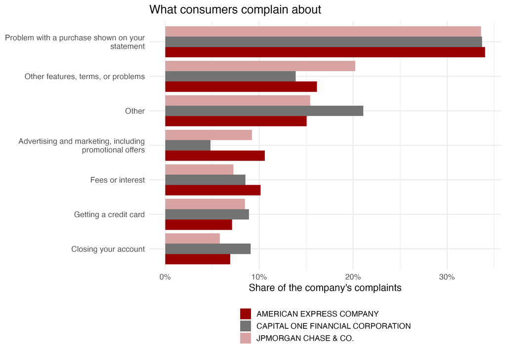

**For a marketing audience**

“Advertising and marketing, including promotional offers” is a top complaint: about 11% of American Express complaints against about 5% for Capital One.

## Before Scraping Anything

### SEC EDGAR and CFPB

- **Access policy:** public data with official access routes
- **Conditions:** EDGAR needs your email and under 10 requests per second; CFPB offers an open API
- **Verdict:** fine for research, as in Hands-on 2 and the complaints demo

### Great Place To Work

- **robots.txt:** list pages are not blocked
- **Terms of use:** no “spider, robot, or other automated mechanism”
- **Verdict:** ask for permission or data before collecting anything

**Division of labor**

The agent can run this check in seconds. Deciding what to do with it is still the researcher’s job.

## Measure Sentiment Two Ways

HANDS-ON

03

Switch to your laptop

Measure Sentiment Two Ways

2,000 Amazon Health & Personal Care reviews, 400 per star rating

- Start LM Studio’s server with **Gemma 4 E4B**
- Open Claude Code in the `handson3_reviews` folder
- **Track A:** score every review with a word dictionary
- **Track B:** code 50 reviews with the local model
- Check both against the star ratings

Prompts in `exercise_prompts.md`, in R (or Python).

## How Code Talks to a Local Model

**Claude Code**  
writes the R script

→

**Your R script**  
sends each review

→

**LM Studio server**  
localhost:1234

→

**Gemma 4 E4B**  
returns codes as JSON

```r
request("http://localhost:1234/v1/chat/completions") |>
  req_body_json(list(
    model = "google/gemma-4-e4b",
    temperature = 0,
    messages = list(list(role = "user",
      content = "Positive or negative? 'Did not work.'")))) |>
  req_perform()
```

```
#> "Negative"
```

- Same request format as OpenAI’s API, so any language works
- **No API key, no cost**, and no data leave the laptop
- `temperature = 0` and a JSON schema make the output reproducible and parseable

## Where Dictionaries Fail

Phrases the dictionary scores as positive

| Phrase | Times in sample |
| --- | --- |
| not **work** | 45 |
| not **recommend** | 33 |
| doesn’t **work** | 25 |
| didn’t **work** | 21 |
| not **worth** | 16 |

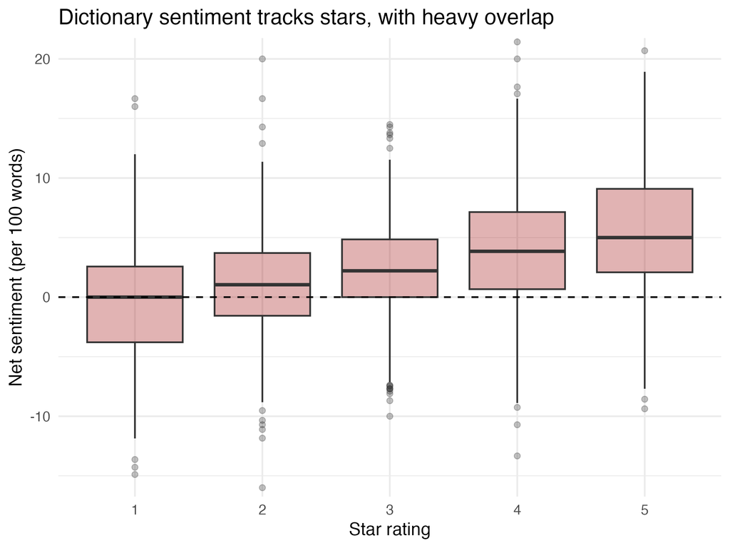

**Result**

The dictionary scores **35% of 1-star reviews** as positive.

## A Local LLM Reads Sentiment Better

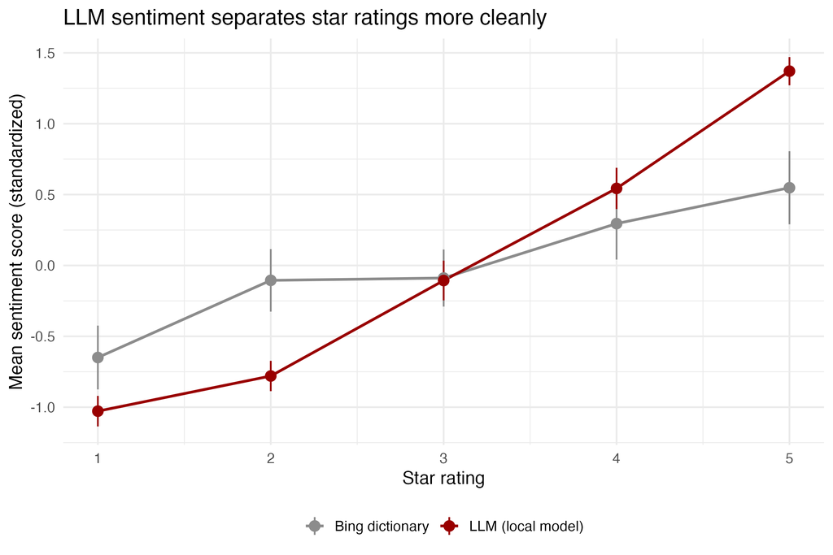

|  | Dictionary | LLM |
| --- | --- | --- |
| Correlation with stars | 0.38 | **0.87** |
| 1-star read as negative | 52% | **93%** |

**Why**

The model reads “did not work” as one idea, not two words.

## What Drives Complaints

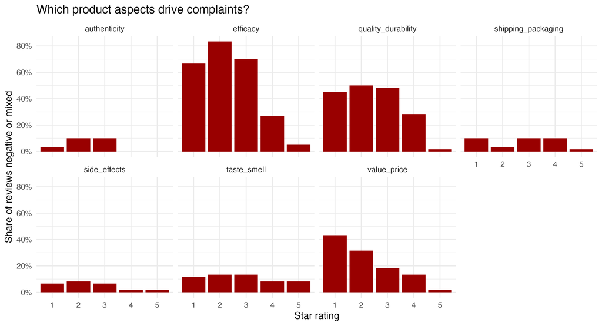

**Takeaway**

**Efficacy** dominates low ratings at every level. Value complaints fall steadily with stars. The categories came from a codebook we wrote, not from the model.

## The Codebook Is the Instrument

### Treat LLM coding as measurement

- Write the codebook in plain English
- Fix the model, version, and temperature (0)
- Save every raw output
- Report the prompt in the appendix

### Validate before you use it

- Hand-code 50 reviews **without** seeing the LLM codes
- Report Cohen’s kappa per category
- Read the disagreements: 63 reviews where dictionary and LLM disagree

**Rule of thumb**

An unvalidated LLM measure is a hunch. A validated one is a variable.

The codebook

## Takeaways

1. **Agents produce scripts, not answers.** That is what makes them auditable.
2. **Skills encode how you work.** Write them once and the agent follows them every time.
3. **AI measures need validation.** The LLM beat the dictionary here, and we know that only because we checked.

**Bottom line**

Use AI to do more of the work, and keep the judgment and the audit trail with you.

## Resources

### Responsible use in research

Blanchard, S. J., N. Duani, A. M. Garvey, O. Netzer, and T. T. Oh (2025), “New Tools, New Rules: A Practical Guide to Effective and Responsible Generative AI Use for Surveys and Experiments in Research,” *Journal of Marketing*, 89 (6), 119–139.  
doi.org/10.1177/00222429251349882

### A Claude Code setup for academics

Sant’Anna, P. H. C., “My Claude Code Setup,” Emory University. A template for slides, papers, analyses, and replication packages with review agents and quality gates.  
[psantanna.com/claude-code-my-workflow](https://psantanna.com/claude-code-my-workflow/)

## Thank You

Thank You

Questions & Comments?

Muzeeb Shaik

shaikmu@iu.edu

[figure not shown]

**Standing on the shoulders of giants.** Everything today rests on others' data, tools, and research.

**But this giant is blind.** The AI has the strength; the researcher on its shoulders sees the way.

Nicolas Poussin, *Blind Orion Searching for the Rising Sun* (1658), detail.  
The Metropolitan Museum of Art, Open Access (CC0).

# Appendix

## Tools and Setup

### Software used today

- **Claude Code** (desktop app, Code tab)
- **Positron** with the Claude Code extension
- **R**, **Python**, **Stata**: whichever the project uses
- **LM Studio** for local models (Gemma 4B, Qwen 27B)

### Local model settings

- Temperature 0
- JSON schema enforced, so every reply parses
- About 1.7 seconds per review on a laptop
- 300 reviews coded, 0 parse failures

◂ Back to takeaways

## The Codebook

Each aspect is coded **positive**, **negative**, **mixed**, or **not mentioned**.

| Aspect | Definition |
| --- | --- |
| Efficacy | Whether the product does what it promises |
| Side effects | Physical reactions such as stomach upset, rash, headache |
| Taste and smell | Taste, flavor, scent, or odor |
| Value and price | Price, value for money, cost relative to alternatives |
| Quality and durability | Build quality, materials, breaking, lasting |
| Shipping and packaging | Delivery, damaged or missing items, seals |
| Authenticity | Doubts that the product is genuine, expired, or tampered with |

Plus an **overall sentiment** score (1 to 5) and the **main issue** in at most eight words.

◂ Back to validation

## Script Map

| Script | What it does | Run time |
| --- | --- | --- |
| `01_load_sample.R` | Reads 494K reviews, filters, draws 400 per star | 45 sec |
| `02_classical.R` | Word counts, tf-idf, negation, dictionary sentiment, LDA | 5 sec |
| `03_llm_lmstudio.R` | Local LLM coding, comparison, aspects, validation sheet | 8.5 min |

Data: Hou et al. (2024), *Amazon Reviews 2023*, McAuley Lab, UC San Diego.

◂ Back to takeaways